# Project

2024-10-01

the data sets were dowmload from the following websites:

https://lms.uwa.edu.au/bbcswebdav/pid-3998436-dt-content-rid-47695412_1/courses/CITS4009_SEM-2_2024/Countries%20and%20death%20causes.csv

https://aus01.safelinks.protection.outlook.com/?url=https%3A%2F%2Fdata.worldbank.org%2Findicator%2FSP.POP.TOTL&data=05%7C02%7Cghulam.hassan%40uwa.edu.au%7Cc20b22f931c04562a9fb08dcd2f7f6ed%7C05894af0cb2846d8871674cdb46e2226%7C0%7C0%7C638617211073985280%7CUnknown%7CTWFpbGZsb3d8eyJWIjoiMC4wLjAwMDAiLCJQIjoiV2luMzIiLCJBTiI6Ik1haWwiLCJXVCI6Mn0%3D%7C0%7C%7C%7C&sdata=SqeFeXpn3iWpCnz5DM3YGQ2VXYM4c1vmGh48%2FI9NoYE%3D&reserved=0

https://data.worldbank.org/indicator/NY.GDP.PCAP.CD

# 1. Data preparation and exploration

This project is about exploring the death rate caused by unsanitary factors based on socioeconomic status (measured by GDP per capita) and population size. Therefore, I want to create a dataset that includes only the year, death rate, GDP per capita, and population for use in classification and clustering.

## 1.1 Load required libraries

```r
library(dplyr)
```

```r
library(magrittr)
library(ggplot2)
library(shiny)
library(tidyr)
library(vtreat)
library(zoo)
library(caret)
library(rpart)
library(rpart.plot)
library(ROCR)
library(e1071)
library(class)
library(lime)
library(fpc)
library(FSelector)
library(gridExtra)
library(GGally)
```

## 1.2 Read the csv files downloaded from WHO and worldbank websites

The ‘Year’ variable exists in death_data data set where each observation represents the number of deaths by different causes for a specific country in a particular year. In the population(pop_data) and GDP per capita(pcap_data) data sets, years are treated as variable names, where each observation represents the population or GDP per capita of a country from 1960 to 2023.

```r
# Read the Countries and death causes file
death_data <- read.csv("C:/Users/86180/Desktop/CITS4009R/Project/Countries and death causes.csv", header=TRUE, check.names=FALSE, stringsAsFactors=FALSE)

# Read the gdp per capita file, and skip the first 4 rows as it contains unnecessary information
pcap_data <- read.csv("C:/Users/86180/Desktop/CITS4009R/Project/GDP_PCAP.csv", skip=4, header=TRUE, stringsAsFactors=FALSE)

# Read the population file, and skip the first 4 rows as it contains unnecessary information
pop_data <- read.csv("C:/Users/86180/Desktop/CITS4009R/Project/POP.csv", skip=4, header=TRUE, stringsAsFactors=FALSE)

# View the first 6 rows of the data sets
head(death_data)
```

|  | Entity | Code | Year | Outdoor air pollution | High systolic blood pressure | Diet high in sodium | Diet low in whole grains | Alochol use | Diet low in fruits | Unsafe water source | Secondhand smoke | Low birth weight | Child wasting | Unsafe sex | Diet low in nuts and seeds | Household air pollution from solid fuels | Diet low in Vegetables | Low physical activity | Smoking | High fasting plasma glucose | Air pollution | High body mass index | Unsafe sanitation | No access to handwashing facility | Drug use | Low bone mineral density | Vitamin A deficiency | Child stunting | Discontinued breastfeeding | … |
| --- | --- | --- | --- | --- | --- | --- | --- | --- | --- | --- | --- | --- | --- | --- | --- | --- | --- | --- | --- | --- | --- | --- | --- | --- | --- | --- | --- | --- | --- | --- |
| 1 | Afghanistan | AFG | 1990 | 3169 | 25633 | 1045 | 7077 | 356 | 3185 | 3702 | 4794 | 16135 | 19546 | 351 | 2319 | 34372 | 3679 | 2637 | 5174 | 11449 | 37231 | 9518 | 2798 | 4825 | 174 | 389 | 2016 | 7686 | 107 | … |
| 2 | Afghanistan | AFG | 1991 | 3222 | 25872 | 1055 | 7149 | 364 | 3248 | 4309 | 4921 | 17924 | 20334 | 361 | 2449 | 35392 | 3732 | 2652 | 5247 | 11811 | 38315 | 9489 | 3254 | 5127 | 188 | 389 | 2056 | 7886 | 121 | … |
| 3 | Afghanistan | AFG | 1992 | 3395 | 26309 | 1075 | 7297 | 376 | 3351 | 5356 | 5279 | 21200 | 22895 | 378 | 2603 | 38065 | 3827 | 2688 | 5363 | 12265 | 41172 | 9528 | 4042 | 5889 | 211 | 393 | 2100 | 8568 | 150 | … |
| 4 | Afghanistan | AFG | 1993 | 3623 | 26961 | 1103 | 7499 | 389 | 3480 | 7152 | 5734 | 23795 | 27002 | 395 | 2771 | 41154 | 3951 | 2744 | 5522 | 12821 | 44488 | 9611 | 5392 | 7007 | 232 | 411 | 2316 | 9875 | 204 | … |
| 5 | Afghanistan | AFG | 1994 | 3788 | 27658 | 1134 | 7698 | 399 | 3610 | 7192 | 6050 | 24866 | 29205 | 410 | 2932 | 43153 | 4075 | 2805 | 5689 | 13400 | 46634 | 9675 | 5418 | 7421 | 247 | 413 | 2665 | 11031 | 204 | … |
| 6 | Afghanistan | AFG | 1995 | 3869 | 28090 | 1154 | 7807 | 406 | 3703 | 8378 | 6167 | 25534 | 30943 | 422 | 3049 | 44024 | 4153 | 2839 | 5801 | 13871 | 47566 | 9608 | 6313 | 7896 | 260 | 417 | 3070 | 11973 | 233 | … |

```r
head(pcap_data)
```

|  | Country.Name | Country.Code | Indicator.Name | Indicator.Code | X1960 | X1961 | X1962 | X1963 | X1964 | X1965 | X1966 | X1967 | X1968 | X1969 | X1970 | X1971 | X1972 | X1973 | X1974 | X1975 | X1976 | X1977 | X1978 | X1979 | X1980 | X1981 | X1982 | X1983 | X1984 | … |
| --- | --- | --- | --- | --- | --- | --- | --- | --- | --- | --- | --- | --- | --- | --- | --- | --- | --- | --- | --- | --- | --- | --- | --- | --- | --- | --- | --- | --- | --- | --- |
| 1 | Aruba | ABW | GDP per capita (current US$) | NY.GDP.PCAP.CD | NA | NA | NA | NA | NA | NA | NA | NA | NA | NA | NA | NA | NA | NA | NA | NA | NA | NA | NA | NA | NA | NA | NA | NA | NA | … |
| 2 | Africa Eastern and Southern | AFE | GDP per capita (current US$) | NY.GDP.PCAP.CD | 162.3425 | 166.2637 | 171.9619 | 182.0185 | 192.6400 | 202.8478 | 214.6669 | 226.9789 | 237.9114 | 256.3564 | 253.3824 | 268.3501 | 282.7370 | 354.4988 | 421.9772 | 435.9779 | 430.2612 | 468.3010 | 509.4799 | 578.5632 | 728.0890 | 747.0455 | 689.9427 | 711.6782 | 638.7481 | … |
| 3 | Afghanistan | AFG | GDP per capita (current US$) | NY.GDP.PCAP.CD | NA | NA | NA | NA | NA | NA | NA | NA | NA | NA | NA | NA | NA | NA | NA | NA | NA | NA | NA | NA | NA | NA | NA | NA | NA | … |
| 4 | Africa Western and Central | AFW | GDP per capita (current US$) | NY.GDP.PCAP.CD | 122.1939 | 127.7328 | 134.1301 | 139.2912 | 148.8214 | 156.3141 | 162.8907 | 145.5681 | 146.8465 | 162.7213 | 219.8654 | 197.1039 | 231.5718 | 282.6424 | 370.9350 | 416.4407 | 484.1221 | 494.6891 | 527.9865 | 630.0173 | 763.5078 | 1336.2900 | 1172.9970 | 881.4229 | 745.3269 | … |
| 5 | Angola | AGO | GDP per capita (current US$) | NY.GDP.PCAP.CD | NA | NA | NA | NA | NA | NA | NA | NA | NA | NA | NA | NA | NA | NA | NA | NA | NA | NA | NA | NA | NA | NA | NA | NA | NA | … |
| 6 | Albania | ALB | GDP per capita (current US$) | NY.GDP.PCAP.CD | NA | NA | NA | NA | NA | NA | NA | NA | NA | NA | NA | NA | NA | NA | NA | NA | NA | NA | NA | NA | NA | NA | NA | NA | 639.4847 | … |

```r
head(pop_data)
```

|  | Country.Name | Country.Code | Indicator.Name | Indicator.Code | X1960 | X1961 | X1962 | X1963 | X1964 | X1965 | X1966 | X1967 | X1968 | X1969 | X1970 | X1971 | X1972 | X1973 | X1974 | X1975 | X1976 | X1977 | X1978 | X1979 | X1980 | X1981 | X1982 | X1983 | X1984 | … |
| --- | --- | --- | --- | --- | --- | --- | --- | --- | --- | --- | --- | --- | --- | --- | --- | --- | --- | --- | --- | --- | --- | --- | --- | --- | --- | --- | --- | --- | --- | --- |
| 1 | Aruba | ABW | Population, total | SP.POP.TOTL | 54608 | 55811 | 56682 | 57475 | 58178 | 58782 | 59291 | 59522 | 59471 | 59330 | 59106 | 58816 | 58855 | 59365 | 60028 | 60715 | 61193 | 61465 | 61738 | 62006 | 62267 | 62614 | 63116 | 63683 | 64174 | … |
| 2 | Africa Eastern and Southern | AFE | Population, total | SP.POP.TOTL | 130692579 | 134169237 | 137835590 | 141630546 | 145605995 | 149742351 | 153955516 | 158313235 | 162875171 | 167596160 | 172475766 | 177503186 | 182599092 | 187901657 | 193512956 | 199284304 | 205202669 | 211120911 | 217481420 | 224315978 | 230967858 | 237937461 | 245386717 | 252779730 | 260209149 | … |
| 3 | Afghanistan | AFG | Population, total | SP.POP.TOTL | 8622466 | 8790140 | 8969047 | 9157465 | 9355514 | 9565147 | 9783147 | 10010030 | 10247780 | 10494489 | 10752971 | 11015857 | 11286753 | 11575305 | 11869879 | 12157386 | 12425267 | 12687301 | 12938862 | 12986369 | 12486631 | 11155195 | 10088289 | 9951449 | 10243686 | … |
| 4 | Africa Western and Central | AFW | Population, total | SP.POP.TOTL | 97256290 | 99314028 | 101445032 | 103667517 | 105959979 | 108336203 | 110798486 | 113319950 | 115921723 | 118615741 | 121424797 | 124336039 | 127364044 | 130563107 | 133953892 | 137548613 | 141258400 | 145122851 | 149206663 | 153459665 | 157825609 | 162323313 | 167023385 | 171566640 | 176054495 | … |
| 5 | Angola | AGO | Population, total | SP.POP.TOTL | 5357195 | 5441333 | 5521400 | 5599827 | 5673199 | 5736582 | 5787044 | 5827503 | 5868203 | 5928386 | 6029700 | 6177049 | 6364731 | 6578230 | 6802494 | 7032713 | 7266780 | 7511895 | 7771590 | 8043218 | 8330047 | 8631457 | 8947152 | 9276707 | 9617702 | … |
| 6 | Albania | ALB | Population, total | SP.POP.TOTL | 1608800 | 1659800 | 1711319 | 1762621 | 1814135 | 1864791 | 1914573 | 1965598 | 2022272 | 2081695 | 2135479 | 2187853 | 2243126 | 2296752 | 2350124 | 2404831 | 2458526 | 2513546 | 2566266 | 2617832 | 2671997 | 2726056 | 2784278 | 2843960 | 2904429 | … |

## 1.3 Create the Year variable

The “Year” variable only exists in the death_data, while years exist as column names in the other data sets. What we want to do is to match the Country and Year variables from the data sets in order to explore the relationships among different variables. Therefore, we need to convert these two data sets into long format to get a new variable called “Year”. And we only explore the data after 1990 as the death_data data set does not records before that year.

In the death_data, some column names are not valid due to spaces, so we need to modify them. In pcap_data and pop_data, R added an “X” at the beginning of the variable names that start with numbers to make them valid. We need to remove the “X” during preprocessing.

```r
# Convert the variable names in death_data to ensure they are valid R variable names
names(death_data) <- make.names(names(death_data), unique = TRUE)

# Convert pop_data and pcap_data into long format to create a new variable called "Year"
pop_data_long <- pop_data %>%
  pivot_longer(cols = starts_with("X"), names_to = "Year", values_to = "population") %>%
  mutate(Year = as.numeric(gsub("^X", "", Year))) %>%
  filter(Year >= 1990)

pcap_data_long <- pcap_data %>%
  pivot_longer(cols = starts_with("X"), names_to = "Year", values_to = "gdp.pcap") %>%
  mutate(Year = as.numeric(gsub("^X", "", Year))) %>%
  filter(Year >= 1990)

# View the converted data set
head(pcap_data_long)
```

| Country.Name | Country.Code | Indicator.Name | Indicator.Code | Year | gdp.pcap |
| --- | --- | --- | --- | --- | --- |
| Aruba | ABW | GDP per capita (current US$) | NY.GDP.PCAP.CD | 1990 | 11638.73 |
| Aruba | ABW | GDP per capita (current US$) | NY.GDP.PCAP.CD | 1991 | 12850.22 |
| Aruba | ABW | GDP per capita (current US$) | NY.GDP.PCAP.CD | 1992 | 13657.67 |
| Aruba | ABW | GDP per capita (current US$) | NY.GDP.PCAP.CD | 1993 | 14970.15 |
| Aruba | ABW | GDP per capita (current US$) | NY.GDP.PCAP.CD | 1994 | 16675.28 |
| Aruba | ABW | GDP per capita (current US$) | NY.GDP.PCAP.CD | 1995 | 17140.43 |

```r
head(pop_data_long)
```

| Country.Name | Country.Code | Indicator.Name | Indicator.Code | Year | population |
| --- | --- | --- | --- | --- | --- |
| Aruba | ABW | Population, total | SP.POP.TOTL | 1990 | 65712 |
| Aruba | ABW | Population, total | SP.POP.TOTL | 1991 | 67864 |
| Aruba | ABW | Population, total | SP.POP.TOTL | 1992 | 70192 |
| Aruba | ABW | Population, total | SP.POP.TOTL | 1993 | 72360 |
| Aruba | ABW | Population, total | SP.POP.TOTL | 1994 | 74710 |
| Aruba | ABW | Population, total | SP.POP.TOTL | 1995 | 77050 |

```r
summary(pcap_data_long)
```

```
##  Country.Name       Country.Code       Indicator.Name     Indicator.Code
##  Length:9044        Length:9044        Length:9044        Length:9044
##  Class :character   Class :character   Class :character   Class :character
##  Mode  :character   Mode  :character   Mode  :character   Mode  :character
##
##
##
##
##       Year         gdp.pcap
##  Min.   :1990   Min.   :    22.85
##  1st Qu.:1998   1st Qu.:  1148.77
##  Median :2006   Median :  3816.38
##  Mean   :2006   Mean   : 12196.07
##  3rd Qu.:2015   3rd Qu.: 14490.17
##  Max.   :2023   Max.   :240862.18
##                 NA's   :461
```

```r
summary(pop_data_long)
```

```
##  Country.Name       Country.Code       Indicator.Name     Indicator.Code
##  Length:9044        Length:9044        Length:9044        Length:9044
##  Class :character   Class :character   Class :character   Class :character
##  Mode  :character   Mode  :character   Mode  :character   Mode  :character
##
##
##
##
##       Year        population
##  Min.   :1990   Min.   :9.182e+03
##  1st Qu.:1998   1st Qu.:1.369e+06
##  Median :2006   Median :8.922e+06
##  Mean   :2006   Mean   :2.676e+08
##  3rd Qu.:2015   3rd Qu.:5.693e+07
##  Max.   :2023   Max.   :8.025e+09
##                 NA's   :34
```

## 1.4 Clean the missing values

There are many missing values in the population and gdp.pcap variables after 1990, which could be due to some countries being established after 1990 or lack of records for certain years. We will first deal about the missing values in pcap_data_long and pop_data_long.

```r
# Remove the observations where all the gdp.cap or population data is NA[1]
pcap_data_long <- pcap_data_long %>%
  group_by(Country.Name) %>%
  filter(!all(is.na(gdp.pcap))) %>%
  ungroup()

pop_data_long <- pop_data_long %>%
  group_by(Country.Name) %>%
  filter(!all(is.na(population))) %>%
  ungroup()

# View the data sets. As we can see, there are no NA values in the population variable, but there are still some NAs in gdp.pcap column. And we can reckon that the economic circumstances would not change significantly in several years for a certain country, so we need to do some data transformation.
summary(pcap_data_long)
```

```
##  Country.Name       Country.Code       Indicator.Name     Indicator.Code
##  Length:8908        Length:8908        Length:8908        Length:8908
##  Class :character   Class :character   Class :character   Class :character
##  Mode  :character   Mode  :character   Mode  :character   Mode  :character
##
##
##
##
##       Year         gdp.pcap
##  Min.   :1990   Min.   :    22.85
##  1st Qu.:1998   1st Qu.:  1148.77
##  Median :2006   Median :  3816.38
##  Mean   :2006   Mean   : 12196.07
##  3rd Qu.:2015   3rd Qu.: 14490.17
##  Max.   :2023   Max.   :240862.18
##                 NA's   :325
```

```r
summary(pop_data_long)
```

```
##  Country.Name       Country.Code       Indicator.Name     Indicator.Code
##  Length:9010        Length:9010        Length:9010        Length:9010
##  Class :character   Class :character   Class :character   Class :character
##  Mode  :character   Mode  :character   Mode  :character   Mode  :character
##
##
##
##       Year        population
##  Min.   :1990   Min.   :9.182e+03
##  1st Qu.:1998   1st Qu.:1.369e+06
##  Median :2006   Median :8.922e+06
##  Mean   :2006   Mean   :2.676e+08
##  3rd Qu.:2015   3rd Qu.:5.693e+07
##  Max.   :2023   Max.   :8.025e+09
```

```r
# Perform linear interpolation for missing GDP per capita values, followed by forward and backward filling of remaining NAs
pcap_data_long <- pcap_data_long %>%
  group_by(Country.Name) %>%
  mutate(gdp.pcap = na.approx(gdp.pcap, Year, na.rm = FALSE)) %>%
  mutate(gdp.pcap = na.locf(gdp.pcap, na.rm = FALSE)) %>%  # fill forward
  mutate(gdp.pcap = na.locf(gdp.pcap, fromLast = TRUE, na.rm = FALSE)) %>%  # fill backward
  ungroup()

# View the cleaned data set
summary(pcap_data_long)
```

```
##  Country.Name       Country.Code       Indicator.Name     Indicator.Code
##  Length:8908        Length:8908        Length:8908        Length:8908
##  Class :character   Class :character   Class :character   Class :character
##  Mode  :character   Mode  :character   Mode  :character   Mode  :character
##
##
##
##       Year         gdp.pcap
##  Min.   :1990   Min.   :    22.85
##  1st Qu.:1998   1st Qu.:  1172.67
##  Median :2006   Median :  3896.65
##  Mean   :2006   Mean   : 12578.29
##  3rd Qu.:2015   3rd Qu.: 15797.62
##  Max.   :2023   Max.   :240862.18
```

## 1.5 Add the gdp per capita and population variables

We can see from the boxplot that there are many outliers in gdp.pcap and population, but considering that the data was collected by authoritative organizations and the complexity of real-world society, this paper believes that these outliers are not anomalies and can reflect the true social situation.

```r
# Add GDP per capita and population variables to death_data using inner join where the country and year is matched[2]
death_data <- death_data %>%
  inner_join(pcap_data_long, by = c("Entity" = "Country.Name", "Year" = "Year")) %>%
  inner_join(pop_data_long, by = c("Entity" = "Country.Name", "Year" = "Year"))

# View the merged data set
names(death_data)
```

```
##  [1] "Entity"
##  [2] "Code"
##  [3] "Year"
##  [4] "Outdoor.air.pollution"
##  [5] "High.systolic.blood.pressure"
##  [6] "Diet.high.in.sodium"
##  [7] "Diet.low.in.whole.grains"
##  [8] "Alochol.use"
##  [9] "Diet.low.in.fruits"
## [10] "Unsafe.water.source"
## [11] "Secondhand.smoke"
## [12] "Low.birth.weight"
## [13] "Child.wasting"
## [14] "Unsafe.sex"
## [15] "Diet.low.in.nuts.and.seeds"
```

[output cut: 24 more lines]

```r
summary(death_data)
```

```
##     Entity              Code                Year      Outdoor.air.pollution
##  Length:5250        Length:5250        Min.   :1990   Min.   :      1
##  Class :character   Class :character   1st Qu.:1997   1st Qu.:    433
##  Mode  :character   Mode  :character   Median :2004   Median :   1655
##                                        Mean   :2004   Mean   :  35219
##                                        3rd Qu.:2012   3rd Qu.:   6282
##                                        Max.   :2019   Max.   :4506193
##  High.systolic.blood.pressure Diet.high.in.sodium Diet.low.in.whole.grains
##  Min.   :      14             Min.   :      2.0   Min.   :      3.0
##  1st Qu.:    1806             1st Qu.:    136.0   1st Qu.:    269.2
##  Median :    7208             Median :    855.5   Median :   1153.0
##  Mean   :   90753             Mean   :  16859.6   Mean   :  15447.0
##  3rd Qu.:   23648             3rd Qu.:   2587.8   3rd Qu.:   4527.8
##  Max.   :10845595             Max.   :1885356.0   Max.   :1844836.0
##   Alochol.use      Diet.low.in.fruits Unsafe.water.source Secondhand.smoke
##  Min.   :      1   Min.   :      1    Min.   :      0.0   Min.   :      2.0
##  1st Qu.:    264   1st Qu.:    134    1st Qu.:      7.0   1st Qu.:    206.2
##  Median :   1468   Median :    654    Median :    106.5   Median :    781.0
##  Mean   :  22013   Mean   :   9962    Mean   :  20511.3   Mean   :  12698.5
##  3rd Qu.:   6336   3rd Qu.:   2051    3rd Qu.:   4201.8   3rd Qu.:   2567.5
##  Max.   :2441973   Max.   :1046015    Max.   :2450944.0   Max.   :1304318.0
##  Low.birth.weight    Child.wasting       Unsafe.sex
##  Min.   :      0.0   Min.   :      0   Min.   :      1
##  1st Qu.:    120.0   1st Qu.:     26   1st Qu.:     93
##  Median :    758.5   Median :    311   Median :    539
##  Mean   :  27164.5   Mean   :  23401   Mean   :  12982
##  3rd Qu.:   6934.0   3rd Qu.:   6349   3rd Qu.:   3181
##  Max.   :3033425.0   Max.   :3430422   Max.   :1664813
##  Diet.low.in.nuts.and.seeds Household.air.pollution.from.solid.fuels
##  Min.   :     0             Min.   :      0
##  1st Qu.:    28             1st Qu.:     32
##  Median :   173             Median :    688
##  Mean   :  5233             Mean   :  38079
##  3rd Qu.:  1105             3rd Qu.:   8589
##  Max.   :575139             Max.   :4358214
##  Diet.low.in.Vegetables Low.physical.activity    Smoking
##  Min.   :     1.0       Min.   :     1        Min.   :     11
##  1st Qu.:   104.2       1st Qu.:    91        1st Qu.:    872
##  Median :   514.0       Median :   360        Median :   3900
##  Mean   :  5067.2       Mean   :  6514        Mean   :  73802
```

[output cut: 29 more lines]

```
##  Max.   :33106.00           Max.   :505470.0            Max.   :73461.0
##  Country.Code.x     Indicator.Name.x   Indicator.Code.x      gdp.pcap
##  Length:5250        Length:5250        Length:5250        Min.   :    22.85
##  Class :character   Class :character   Class :character   1st Qu.:   980.81
##  Mode  :character   Mode  :character   Mode  :character   Median :  3477.23
##                                                           Mean   : 11505.52
##                                                           3rd Qu.: 13396.69
##                                                           Max.   :204097.11
##  Country.Code.y     Indicator.Name.y   Indicator.Code.y     population
##  Length:5250        Length:5250        Length:5250        Min.   :9.182e+03
##  Class :character   Class :character   Class :character   1st Qu.:1.490e+06
##  Mode  :character   Mode  :character   Mode  :character   Median :6.570e+06
##                                                           Mean   :7.048e+07
##                                                           3rd Qu.:1.927e+07
##                                                           Max.   :7.743e+09
```

[figure not shown]

```r
# View the outliers for the population and gdp.pcap variable
ggplot(population, aes(y = population)) +
  geom_boxplot(fill = "blue") +
  labs(title = "Boxplot of population for all countries", y = "population") +
  theme_minimal()
```

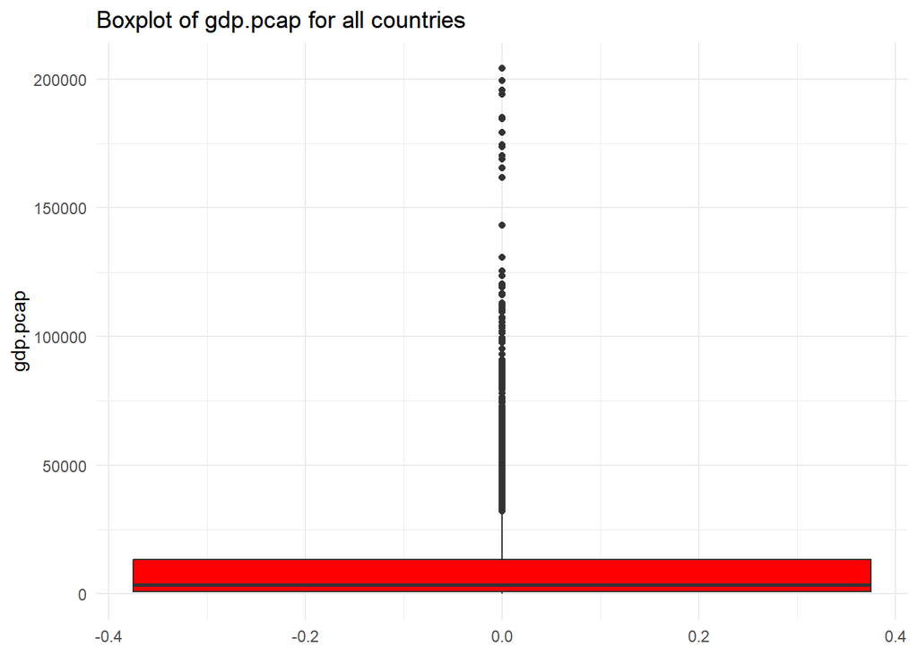

```r
ggplot(death_data, aes(y = gdp.pcap)) +
  geom_boxplot(fill = "red") +
  labs(title = "Boxplot of gdp.pcap for all countries", y = "gdp.pcap") +
  theme_minimal()
```

## 1.6 Add the death.rate variable

Add a new variable named death.rate to death_data. The variables related to insanitation include Unsafe.water.source, No.access.to.handwashing.facility, and Unsafe.sanitation. We can define the death rate due to insanitation as the sum of these three columns divided by the population of that country in the corresponding year.

```r
# Update the data set
death_data <- death_data %>%
  mutate(death.rate = (Unsafe.water.source + No.access.to.handwashing.facility + Unsafe.sanitation) / population)

# View the updated data set
head(death_data)
```

|  | Entity | Code | Year | Outdoor.air.pollution | High.systolic.blood.pressure | Diet.high.in.sodium | Diet.low.in.whole.grains | Alochol.use | Diet.low.in.fruits | Unsafe.water.source | Secondhand.smoke | Low.birth.weight | Child.wasting | Unsafe.sex | Diet.low.in.nuts.and.seeds | Household.air.pollution.from.solid.fuels | Diet.low.in.Vegetables | Low.physical.activity | Smoking | High.fasting.plasma.glucose | Air.pollution | High.body.mass.index | Unsafe.sanitation | No.access.to.handwashing.facility | Drug.use | Low.bone.mineral.density | Vitamin.A.deficiency | Child.stunting | Discontinued.breastfeeding | … |
| --- | --- | --- | --- | --- | --- | --- | --- | --- | --- | --- | --- | --- | --- | --- | --- | --- | --- | --- | --- | --- | --- | --- | --- | --- | --- | --- | --- | --- | --- | --- |
| 1 | Afghanistan | AFG | 1990 | 3169 | 25633 | 1045 | 7077 | 356 | 3185 | 3702 | 4794 | 16135 | 19546 | 351 | 2319 | 34372 | 3679 | 2637 | 5174 | 11449 | 37231 | 9518 | 2798 | 4825 | 174 | 389 | 2016 | 7686 | 107 | … |
| 2 | Afghanistan | AFG | 1991 | 3222 | 25872 | 1055 | 7149 | 364 | 3248 | 4309 | 4921 | 17924 | 20334 | 361 | 2449 | 35392 | 3732 | 2652 | 5247 | 11811 | 38315 | 9489 | 3254 | 5127 | 188 | 389 | 2056 | 7886 | 121 | … |
| 3 | Afghanistan | AFG | 1992 | 3395 | 26309 | 1075 | 7297 | 376 | 3351 | 5356 | 5279 | 21200 | 22895 | 378 | 2603 | 38065 | 3827 | 2688 | 5363 | 12265 | 41172 | 9528 | 4042 | 5889 | 211 | 393 | 2100 | 8568 | 150 | … |
| 4 | Afghanistan | AFG | 1993 | 3623 | 26961 | 1103 | 7499 | 389 | 3480 | 7152 | 5734 | 23795 | 27002 | 395 | 2771 | 41154 | 3951 | 2744 | 5522 | 12821 | 44488 | 9611 | 5392 | 7007 | 232 | 411 | 2316 | 9875 | 204 | … |
| 5 | Afghanistan | AFG | 1994 | 3788 | 27658 | 1134 | 7698 | 399 | 3610 | 7192 | 6050 | 24866 | 29205 | 410 | 2932 | 43153 | 4075 | 2805 | 5689 | 13400 | 46634 | 9675 | 5418 | 7421 | 247 | 413 | 2665 | 11031 | 204 | … |
| 6 | Afghanistan | AFG | 1995 | 3869 | 28090 | 1154 | 7807 | 406 | 3703 | 8378 | 6167 | 25534 | 30943 | 422 | 3049 | 44024 | 4153 | 2839 | 5801 | 13871 | 47566 | 9608 | 6313 | 7896 | 260 | 417 | 3070 | 11973 | 233 | … |

## 1.7 Prepare the data set for modelling and clustering

Extract the variables to form a new data for modelling and clustering, which contains “Entity”, “Year”, “death.rate”, “gdp.pcap” and “population”.

```r
# Create a new data
data <- death_data %>%
  select(Entity, Year, death.rate, gdp.pcap, population)

# View the new data set
names(data)
```

```
## [1] "Entity"     "Year"       "death.rate" "gdp.pcap"   "population"
```

```r
summary(data)
```

```
##     Entity               Year        death.rate           gdp.pcap
##  Length:5250        Min.   :1990   Min.   :0.000e+00   Min.   :    22.85
##  Class :character   1st Qu.:1997   1st Qu.:8.006e-06   1st Qu.:   980.81
##  Mode  :character   Median :2004   Median :7.983e-05   Median :  3477.23
##                     Mean   :2004   Mean   :6.898e-04   Mean   : 11505.52
##                     3rd Qu.:2012   3rd Qu.:8.541e-04   3rd Qu.: 13396.69
##                     Max.   :2019   Max.   :8.730e-03   Max.   :204097.11
##    population
##  Min.   :9.182e+03
##  1st Qu.:1.490e+06
##  Median :6.570e+06
##  Mean   :7.048e+07
##  3rd Qu.:1.927e+07
##  Max.   :7.743e+09
```

## 1.8 Visualise the data

We can conclude that the overall death rate has been decreasing after 1990; the relationship between GDP per capita and the death rate is negatively correlated. we can take China as an example, the higher the GDP per capita, the lower the death rate tends to be.

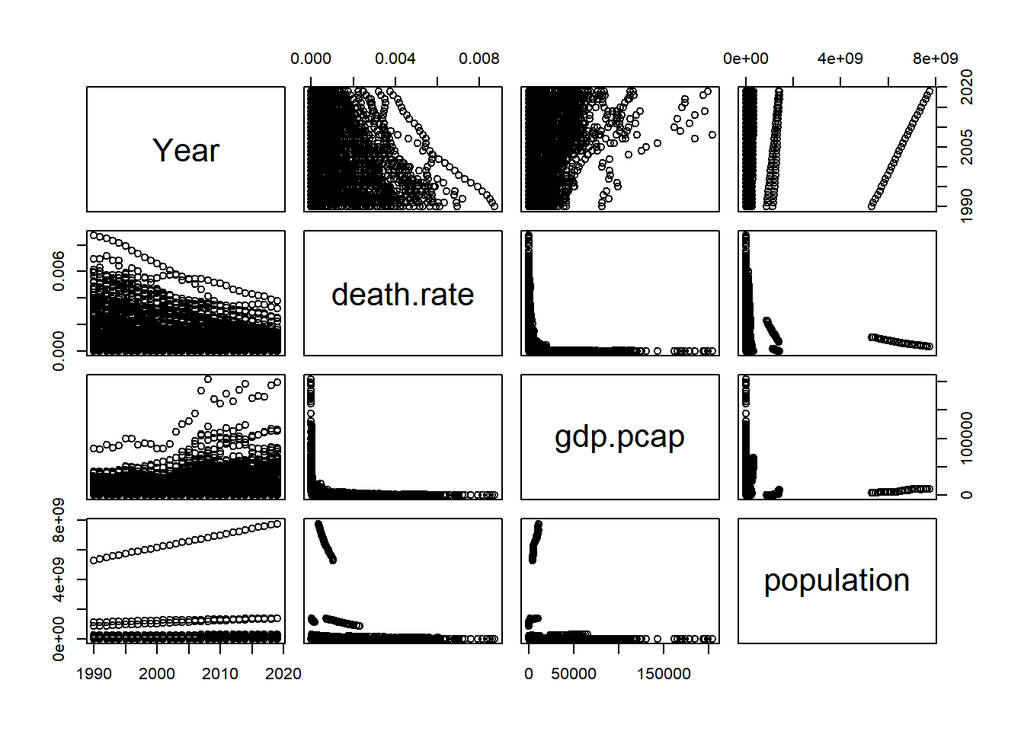

```r
# Scatter plot matrix of selected variables with variables on the diagonal for all countries
pairs(~Year + death.rate + gdp.pcap + population, data = data)
```

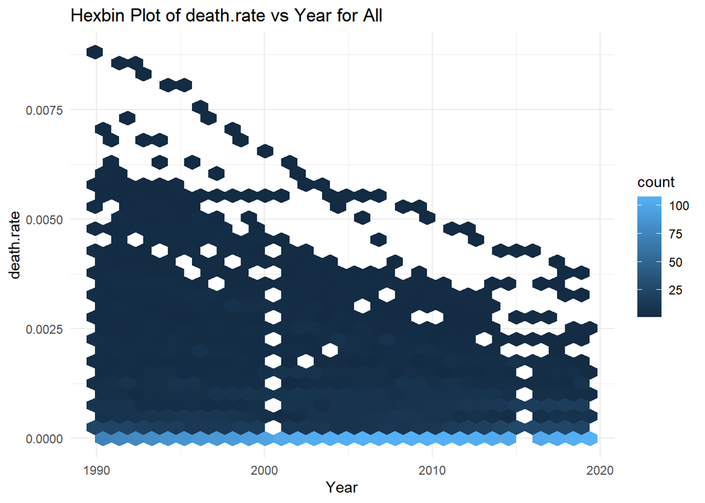

```r
# Hexbin plot for specific variables (e.g., Year and death.rate)
ggplot(data, aes(x = Year, y = death.rate)) +
  geom_hex(bins = 30) +
  labs(title = "Hexbin Plot of death.rate vs Year for All",
       x = "Year",
       y = "death.rate") +
  theme_minimal()
```

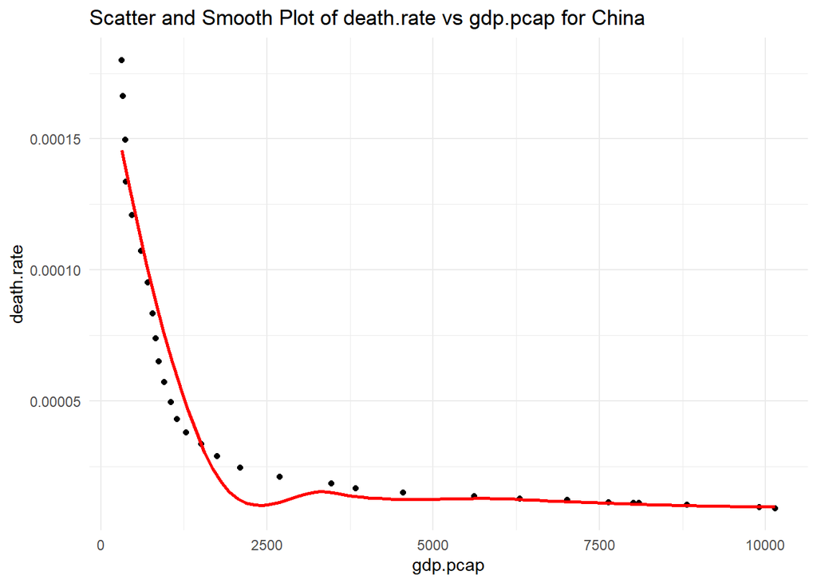

```r
# Scatter and Smooth Plot for death.rate vs gdp.pcap for China
filtered_data <- data %>% filter(Entity == "China")
ggplot(filtered_data, aes(x = gdp.pcap, y = death.rate)) +
  geom_point() +
  geom_smooth(method = "loess", se = FALSE, color = "red") +
  labs(title = "Scatter and Smooth Plot of death.rate vs gdp.pcap for China",
       x = "gdp.pcap",
       y = "death.rate") +
  theme_minimal()
```

# 2. Classification

We use null model, decision tree, and logistic regression models to predict whether the death rates are high or low. Then compare the performance of the three classification models.

Overall both models have excellent performance compared with the null model. The logistic regression model shows higher AUC values than the decision tree model for both the training and test sets, which indicates that the logistic regression model has better overall discrimination ability compared to the decision tree model. But the decision tree model outperforms slightly than the losgitic regression one in terms of accuracy. And the Kappa values between both are close which indicates that they have similar consistency.

## 2.1 Split the training and test set

```r
# Choose death rate category as the response variable. Use the lower quartile as a threshold to define death rates above this value as "high" and below as "low"
threshold <- quantile(data$death.rate, 0.25, na.rm = TRUE)
data <- data %>%
  mutate(death_category = ifelse(death.rate < threshold, "low", "high"))

# Convert death_category to the factor type
data$death_category <- as.factor(data$death_category)

# Set the random seed for reproducibility
set.seed(4009)

# Split the data set: 80% for training, 20% for testing
train_index <- createDataPartition(data$death_category, p = 0.8, list = FALSE)
train_data <- data[train_index, ]
test_data <- data[-train_index, ]

# View training and test data sets
head(train_data)
```

|  | Entity | Year | death.rate | gdp.pcap | population | death_category |
| --- | --- | --- | --- | --- | --- | --- |
| 1 | Afghanistan | 1990 | 0.001058926 | 180.1884 | 10694796 | high |
| 2 | Afghanistan | 1991 | 0.001180996 | 180.1884 | 10745167 | high |
| 3 | Afghanistan | 1992 | 0.001267849 | 180.1884 | 12057433 | high |
| 4 | Afghanistan | 1993 | 0.001396125 | 180.1884 | 14003760 | high |
| 5 | Afghanistan | 1994 | 0.001296039 | 180.1884 | 15455555 | high |
| 6 | Afghanistan | 1995 | 0.001375670 | 180.1884 | 16418912 | high |

```r
head(test_data)
```

|  | Entity | Year | death.rate | gdp.pcap | population | death_category |
| --- | --- | --- | --- | --- | --- | --- |
| 7 | Afghanistan | 1996 | 1.343225e-03 | 180.1884 | 17106595 | high |
| 18 | Afghanistan | 2007 | 8.152629e-04 | 376.3183 | 25903301 | high |
| 19 | Afghanistan | 2008 | 7.146425e-04 | 382.5338 | 26427199 | high |
| 21 | Afghanistan | 2010 | 5.660939e-04 | 562.4992 | 28189672 | high |
| 27 | Afghanistan | 2016 | 3.616158e-04 | 523.0530 | 34636207 | high |
| 35 | Albania | 1994 | 4.707663e-05 | 586.4161 | 3207536 | high |

## 2.2 Calculate feature information gain.

As we can see, the feature “Year” has an information gain of 0 so it can be ignored.

```r
# Calculate information gain for features
info_gain <- information.gain(death_category ~ ., data = train_data)

# View the result of information gain
print(info_gain)
```

```
##            attr_importance
## Entity           0.4971031
## Year             0.0000000
## death.rate       0.5625312
## gdp.pcap         0.2249063
## population       0.1353627
```

```r
# View the sorted information gain
info_gain_sorted <- info_gain[order(-info_gain$attr_importance), ]
print("The sorted Information Gain is:")
```

```
## [1] "The sorted Information Gain is:"
```

```r
print(info_gain_sorted)
```

```
## [1] 0.5625312 0.4971031 0.2249063 0.1353627 0.0000000
```

## 2.3 Null Model for Classification

Null Model is the one that always returns the majority category. It can be Used for comparison with decision tree and logistic regression models.

```r
# Define the most common class in the training data set, then assign it as the prediction for the test data set
most_common_class <- as.character(names(which.max(table(train_data$death_category))))
test_data$null_prediction <- most_common_class

# Define null_prediction with the same factor levels as death_category
test_data$null_prediction <- factor(most_common_class, levels = levels(test_data$death_category))

# Create confusion matrix to evaluate accuracy of the null model. We can found that it always predicts the value as "high"
null_conf_matrix <- confusionMatrix(test_data$null_prediction, test_data$death_category)
print(null_conf_matrix)
```

```
## Confusion Matrix and Statistics
##
##           Reference
## Prediction high low
##       high  787 262
##       low     0   0
##
##                Accuracy : 0.7502
##                  95% CI : (0.7229, 0.7762)
##     No Information Rate : 0.7502
##     P-Value [Acc > NIR] : 0.5166
##
##                   Kappa : 0
##
##  Mcnemar's Test P-Value : <2e-16
##
##             Sensitivity : 1.0000
##             Specificity : 0.0000
##          Pos Pred Value : 0.7502
##          Neg Pred Value :    NaN
##              Prevalence : 0.7502
##          Detection Rate : 0.7502
##    Detection Prevalence : 1.0000
##       Balanced Accuracy : 0.5000
##
##        'Positive' Class : high
##
```

## 2.4 The decision Tree Model

Choose gdp.pcap and population as the feature variables. The tree model illustrates that the lower gdp per capita leads to a higher death rate due to insanitation, which matches the perception.

The confusion matrices show that the decision tree model performs significantly better than the null model as the accuracy is higher than the null model. And the test set accuracy being close to the training accuracy suggests that the model generalizes well and is not overfitting.

The ROC for the Null model indicates a equivalent performance to random guessing as the AUC is 0.5. The ROC curves for training set and Test set are similar and close to the left-top corner, showing that it generalises discrimination well.

```r
# train the decision tree model utilising the train set
tree_model <- rpart(death_category ~ gdp.pcap + population, data = train_data, method = "class")

# View the decision tree model
print(tree_model)
```

```
## n= 4201
##
## node), split, n, loss, yval, (yprob)
##       * denotes terminal node
##
##  1) root 4201 1051 high (0.74982147 0.25017853)
##    2) gdp.pcap< 11157.98 3040  265 high (0.91282895 0.08717105) *
##    3) gdp.pcap>=11157.98 1161  375 low (0.32299742 0.67700258)
##      6) gdp.pcap< 40426.29 799  331 low (0.41426783 0.58573217)
##       12) population< 280692.5 138   34 high (0.75362319 0.24637681) *
##       13) population>=280692.5 661  227 low (0.34341906 0.65658094)
##         26) population>=9.991243e+07 43   12 high (0.72093023 0.27906977) *
##         27) population< 9.991243e+07 618  196 low (0.31715210 0.68284790) *
##      7) gdp.pcap>=40426.29 362   44 low (0.12154696 0.87845304) *
```

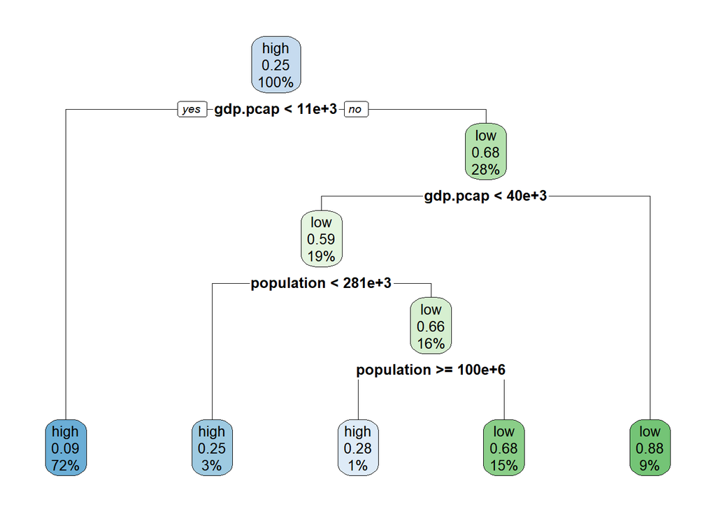

```r
# visualise the decision tree model
rpart.plot(tree_model)
```

```r
# Predict the training set
train_predictions_prob <- predict(tree_model, newdata = train_data, type = "prob")
train_low_prob <- train_predictions_prob[, "low"]
train_predictions <- ifelse(train_low_prob > 0.5, "low", "high")
train_predictions <- as.factor(train_predictions)

# Create confusion matrix for training set
train_conf_matrix <- confusionMatrix(train_predictions, train_data$death_category)
print("Confusion Matrix for Train Data:")
```

```
## [1] "Confusion Matrix for Train Data:"
```

```r
print(train_conf_matrix)
```

```
## Confusion Matrix and Statistics
##
##           Reference
## Prediction high  low
##       high 2910  311
##       low   240  740
##
##                Accuracy : 0.8688
##                  95% CI : (0.8583, 0.8789)
##     No Information Rate : 0.7498
##     P-Value [Acc > NIR] : < 2.2e-16
##
##                   Kappa : 0.6424
##
##  Mcnemar's Test P-Value : 0.002863
##
##             Sensitivity : 0.9238
##             Specificity : 0.7041
##          Pos Pred Value : 0.9034
##          Neg Pred Value : 0.7551
##              Prevalence : 0.7498
##          Detection Rate : 0.6927
##    Detection Prevalence : 0.7667
##       Balanced Accuracy : 0.8140
##
##        'Positive' Class : high
##
```

```r
# Create confusion matrix for test set
test_predictions_prob <- predict(tree_model, newdata = test_data, type = "prob")
test_low_prob <- test_predictions_prob[, "low"]
test_predictions <- ifelse(test_low_prob > 0.5, "low", "high")
test_predictions <- as.factor(test_predictions)
test_conf_matrix <- confusionMatrix(test_predictions, test_data$death_category)
print("Confusion Matrix for Test Data:")
```

```
## [1] "Confusion Matrix for Test Data:"
```

```r
print(test_conf_matrix)
```

```
## Confusion Matrix and Statistics
##
##           Reference
## Prediction high low
##       high  732  94
##       low    55 168
##
##                Accuracy : 0.858
##                  95% CI : (0.8354, 0.8785)
##     No Information Rate : 0.7502
##     P-Value [Acc > NIR] : < 2.2e-16
##
##                   Kappa : 0.6012
##
##  Mcnemar's Test P-Value : 0.001851
##
##             Sensitivity : 0.9301
##             Specificity : 0.6412
##          Pos Pred Value : 0.8862
##          Neg Pred Value : 0.7534
##              Prevalence : 0.7502
##          Detection Rate : 0.6978
##    Detection Prevalence : 0.7874
##       Balanced Accuracy : 0.7857
##
##        'Positive' Class : high
##
```

```r
# Create confusion matrix for null model
null_predictions <- rep(most_common_class, nrow(test_data))
null_predictions <- factor(null_predictions, levels = levels(test_data$death_category))
null_conf_matrix <- confusionMatrix(null_predictions, test_data$death_category)
print("Confusion Matrix for Null Model:")
```

```
## [1] "Confusion Matrix for Null Model:"
```

```r
print(null_conf_matrix)
```

```
## Confusion Matrix and Statistics
##
##           Reference
## Prediction high low
##       high  787 262
##       low     0   0
##
##                Accuracy : 0.7502
##                  95% CI : (0.7229, 0.7762)
##     No Information Rate : 0.7502
##     P-Value [Acc > NIR] : 0.5166
##
##                   Kappa : 0
##
##  Mcnemar's Test P-Value : <2e-16
##
##             Sensitivity : 1.0000
##             Specificity : 0.0000
##          Pos Pred Value : 0.7502
##          Neg Pred Value :    NaN
##              Prevalence : 0.7502
##          Detection Rate : 0.7502
##    Detection Prevalence : 1.0000
##       Balanced Accuracy : 0.5000
##
##        'Positive' Class : high
##
```

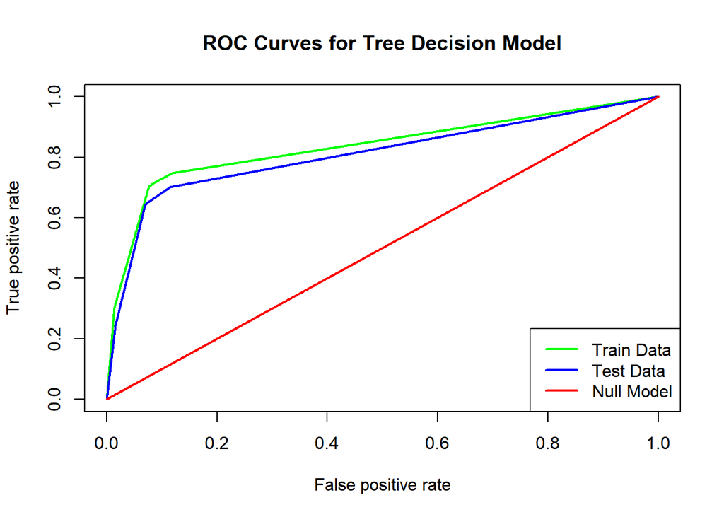

```r
# Plot ROC curve for training set
tree_train_pred <- prediction(train_low_prob, train_data$death_category)
tree_train_perf <- performance(tree_train_pred, "tpr", "fpr")

# Plot ROC curve for test set
tree_test_pred <- prediction(test_low_prob, test_data$death_category)
tree_test_perf <- performance(tree_test_pred, "tpr", "fpr")

# Null model ROC curve
null_prob <- rep(0.5, nrow(test_data))
null_pred <- prediction(null_prob, test_data$death_category)
null_perf <- performance(null_pred, "tpr", "fpr")

# Plot all ROC curves on the same graph
plot(tree_train_perf, col = "green", lwd = 2, main = "ROC Curves for Tree Decision Model")
plot(tree_test_perf, col = "blue", lwd = 2, add = TRUE)
plot(null_perf, col = "red", lwd = 2, add = TRUE)
legend("bottomright", legend = c("Train Data", "Test Data", "Null Model"), col = c("green", "blue", "red"), lwd = 2)
```

```r
# Calculate AUC
train_auc_perf <- performance(tree_train_pred, "auc")
train_auc_value <- train_auc_perf@y.values[[1]]
print(paste("AUC for Train Data:", train_auc_value))
```

```
## [1] "AUC for Train Data: 0.834464380106625"
```

```r
test_auc_perf <- performance(tree_test_pred, "auc")
test_auc_value <- test_auc_perf@y.values[[1]]
print(paste("AUC for Test Data:", test_auc_value))
```

```
## [1] "AUC for Test Data: 0.809606487094678"
```

```r
null_auc_perf <- performance(null_pred, "auc")
null_auc_value <- null_auc_perf@y.values[[1]]
print(paste("AUC for Null Model:", null_auc_value))
```

```
## [1] "AUC for Null Model: 0.5"
```

## 2.5 Using Lime to find the determing deatures for the decision tree model

As we can see, for the random 4 cases, the probability values are all 0.91, indicating that the model has rather high confidence for the prediction result. And we found that the gdp.pcap has more significant influence for the prediction than the population feature.

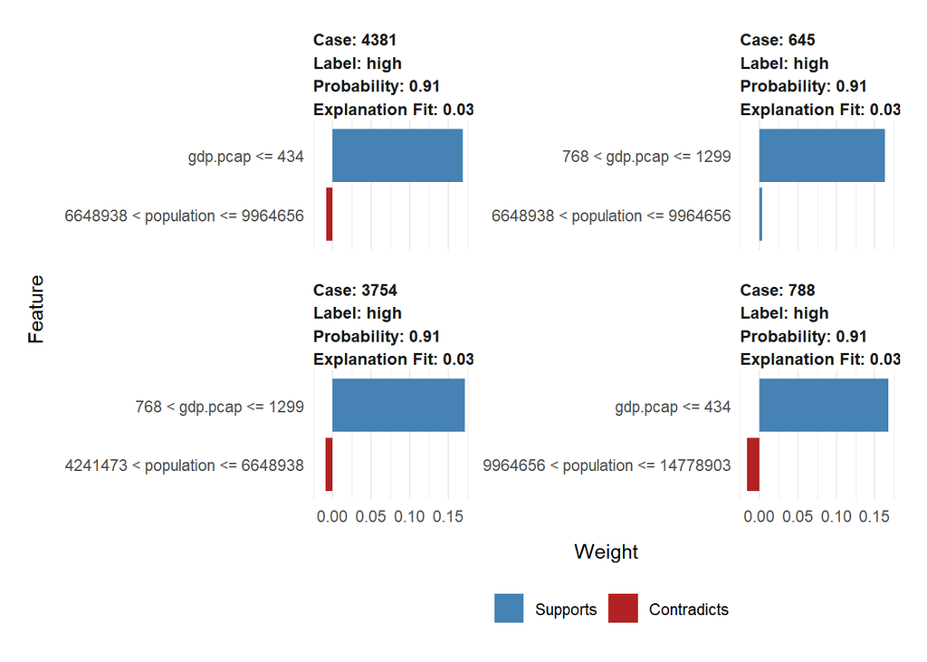

```r
# Define model_type function, while the type is rpart
model_type.rpart <- function(x, ...) {
  return("classification")
}

# Define predict_model function
predict_model.rpart <- function(model, newdata, type, ...) {
  predictions <- predict(model, newdata, type = "prob")
  data.frame(low = predictions[, "low"], high = predictions[, "high"])
}

# Register to the global environment[3]
assign("model_type.rpart", model_type.rpart, envir = .GlobalEnv)
assign("predict_model.rpart", predict_model.rpart, envir = .GlobalEnv)

# Select the feature variables
features <- c("gdp.pcap", "population")

# Create an explainer for the decision tree model
explainer_tree <- lime(train_data[features], model = tree_model, bin_continuous = TRUE, n_bins = 10)


# Select the random test data samples to explain
set.seed(4009)
cases <- sample(1:nrow(test_data), 4)
example <- test_data[cases, features]

# Explain the decision tree model
explanation_tree <- lime::explain(example, explainer_tree, n_labels = 1, n_features = 4)


# Visualise the explanation of the decision tree model
plot_features(explanation_tree)
```

## 2.6 Logistic regression model

Choose gdp.pcap and population as the feature variables. At first the model performed poorly, as the auc value was lower than 0.2 and the accuracy in the confusion matrices was not satisfied, which means that it worked much worse than random guessing. So I decided to predict the death rate in reverse, meaning that I make the prediction probabilities higher than 0.25 as “low”, and vice versa. Then it works well.

Both the coefficients gdp.pcap and population have rather small Pr(>|z|) values which means that both of them significantly affect the model. And the deviance is smaller than the null model, indicating that the model has reduced the deiance.

The training and test set accuracies are 84.74% and 84.65% respectively. This indicates that the logistic regression model performs well in accuracy and consistency.

The ROC for the Null model indicates a equivalent performance to random guessing. The ROC curves for training set and Test set are similar and the area is higher than the null model, showing good classification ability.

```r
# Train the logistic regression model
logit_model <- glm(death_category ~ gdp.pcap + population, data = train_data, family = "binomial")
# View the logistic regression model
summary(logit_model)
```

```
##
## Call:
## glm(formula = death_category ~ gdp.pcap + population, family = "binomial",
##     data = train_data)
##
## Coefficients:
##               Estimate Std. Error z value Pr(>|z|)
## (Intercept) -2.270e+00  6.308e-02 -35.986  < 2e-16 ***
## gdp.pcap     9.942e-05  3.593e-06  27.668  < 2e-16 ***
## population  -4.539e-09  1.162e-09  -3.906 9.38e-05 ***
## ---
## Signif. codes:  0 '***' 0.001 '**' 0.01 '*' 0.05 '.' 0.1 ' ' 1
##
## (Dispersion parameter for binomial family taken to be 1)
##
##     Null deviance: 4726.4  on 4200  degrees of freedom
## Residual deviance: 3250.7  on 4198  degrees of freedom
## AIC: 3256.7
##
## Number of Fisher Scoring iterations: 8
```

```r
# Predict the training set
train_predictions_prob <- predict(logit_model, newdata = train_data, type = "response")
train_predictions <- ifelse(train_predictions_prob > 0.25, "low", "high")
train_predictions <- as.factor(train_predictions)

# Create confusion matrix for the training set
train_conf_matrix <- confusionMatrix(train_predictions, train_data$death_category)
print("Confusion Matrix for Train Data:")
```

```
## [1] "Confusion Matrix for Train Data:"
```

```r
print(train_conf_matrix)
```

```
## Confusion Matrix and Statistics
##
##           Reference
## Prediction high  low
##       high 2802  293
##       low   348  758
##
##                Accuracy : 0.8474
##                  95% CI : (0.8362, 0.8582)
##     No Information Rate : 0.7498
##     P-Value [Acc > NIR] : < 2e-16
##
##                   Kappa : 0.6003
##
##  Mcnemar's Test P-Value : 0.03294
##
##             Sensitivity : 0.8895
##             Specificity : 0.7212
##          Pos Pred Value : 0.9053
##          Neg Pred Value : 0.6854
##              Prevalence : 0.7498
##          Detection Rate : 0.6670
##    Detection Prevalence : 0.7367
##       Balanced Accuracy : 0.8054
##
##        'Positive' Class : high
##
```

```r
# Predict the test set
test_predictions_prob <- predict(logit_model, newdata = test_data, type = "response")
test_predictions <- ifelse(test_predictions_prob > 0.25, "low", "high")
test_predictions <- as.factor(test_predictions)

# Create confusion matrix for the test set
test_conf_matrix <- confusionMatrix(test_predictions, test_data$death_category)
print("Confusion Matrix for Test Data:")
```

```
## [1] "Confusion Matrix for Test Data:"
```

```r
print(test_conf_matrix)
```

```
## Confusion Matrix and Statistics
##
##           Reference
## Prediction high low
##       high  706  80
##       low    81 182
##
##                Accuracy : 0.8465
##                  95% CI : (0.8233, 0.8678)
##     No Information Rate : 0.7502
##     P-Value [Acc > NIR] : 2.252e-14
##
##                   Kappa : 0.591
##
##  Mcnemar's Test P-Value : 1
##
##             Sensitivity : 0.8971
##             Specificity : 0.6947
##          Pos Pred Value : 0.8982
##          Neg Pred Value : 0.6920
##              Prevalence : 0.7502
##          Detection Rate : 0.6730
##    Detection Prevalence : 0.7493
##       Balanced Accuracy : 0.7959
##
##        'Positive' Class : high
##
```

```r
# Create null model confusion matrix
null_predictions <- rep(most_common_class, nrow(test_data))
null_predictions <- factor(null_predictions, levels = levels(test_data$death_category))
null_conf_matrix <- confusionMatrix(null_predictions, test_data$death_category)
print("Confusion Matrix for Null Model:")
```

```
## [1] "Confusion Matrix for Null Model:"
```

```r
print(null_conf_matrix)
```

```
## Confusion Matrix and Statistics
##
##           Reference
## Prediction high low
##       high  787 262
##       low     0   0
##
##                Accuracy : 0.7502
##                  95% CI : (0.7229, 0.7762)
##     No Information Rate : 0.7502
##     P-Value [Acc > NIR] : 0.5166
##
##                   Kappa : 0
##
##  Mcnemar's Test P-Value : <2e-16
##
##             Sensitivity : 1.0000
##             Specificity : 0.0000
##          Pos Pred Value : 0.7502
##          Neg Pred Value :    NaN
##              Prevalence : 0.7502
##          Detection Rate : 0.7502
##    Detection Prevalence : 1.0000
##       Balanced Accuracy : 0.5000
##
##        'Positive' Class : high
##
```

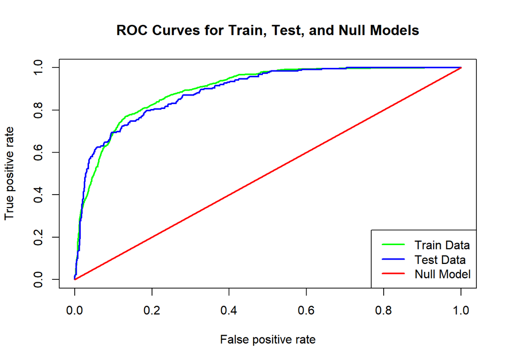

```r
# ROC curve for the training set
logit_train_pred <- prediction(train_predictions_prob, train_data$death_category)
logit_train_perf <- performance(logit_train_pred, "tpr", "fpr")

# ROC curve for the test set
logit_test_pred <- prediction(test_predictions_prob, test_data$death_category)
logit_test_perf <- performance(logit_test_pred, "tpr", "fpr")

# ROC curve for the null model
null_predictions_prob <- rep(0.5, nrow(test_data))
null_pred <- prediction(null_predictions_prob, test_data$death_category)
null_perf <- performance(null_pred, "tpr", "fpr")

# Plot all ROC curves on the same graph
plot(logit_train_perf, col = "green", lwd = 2, main = "ROC Curves for Train, Test, and Null Models")
plot(logit_test_perf, col = "blue", lwd = 2, add = TRUE)
plot(null_perf, col = "red", lwd = 2, add = TRUE)
legend("bottomright", legend = c("Train Data", "Test Data", "Null Model"), col = c("green", "blue", "red"), lwd = 2)
```

```r
# Calculate and view the AUC
train_auc_perf <- performance(logit_train_pred, "auc")
train_auc_value <- train_auc_perf@y.values[[1]]
print(paste("AUC for Train Data:", train_auc_value))
```

```
## [1] "AUC for Train Data: 0.898513887001056"
```

```r
test_auc_perf <- performance(logit_test_pred, "auc")
test_auc_value <- test_auc_perf@y.values[[1]]
print(paste("AUC for Test Data:", test_auc_value))
```

```
## [1] "AUC for Test Data: 0.892887280910212"
```

```r
null_auc_perf <- performance(null_pred, "auc")
null_auc_value <- null_auc_perf@y.values[[1]]
print(paste("AUC for Null Model:", null_auc_value))
```

```
## [1] "AUC for Null Model: 0.5"
```

## 2.7 Using Lime to find the determing deatures for the logistic regression model

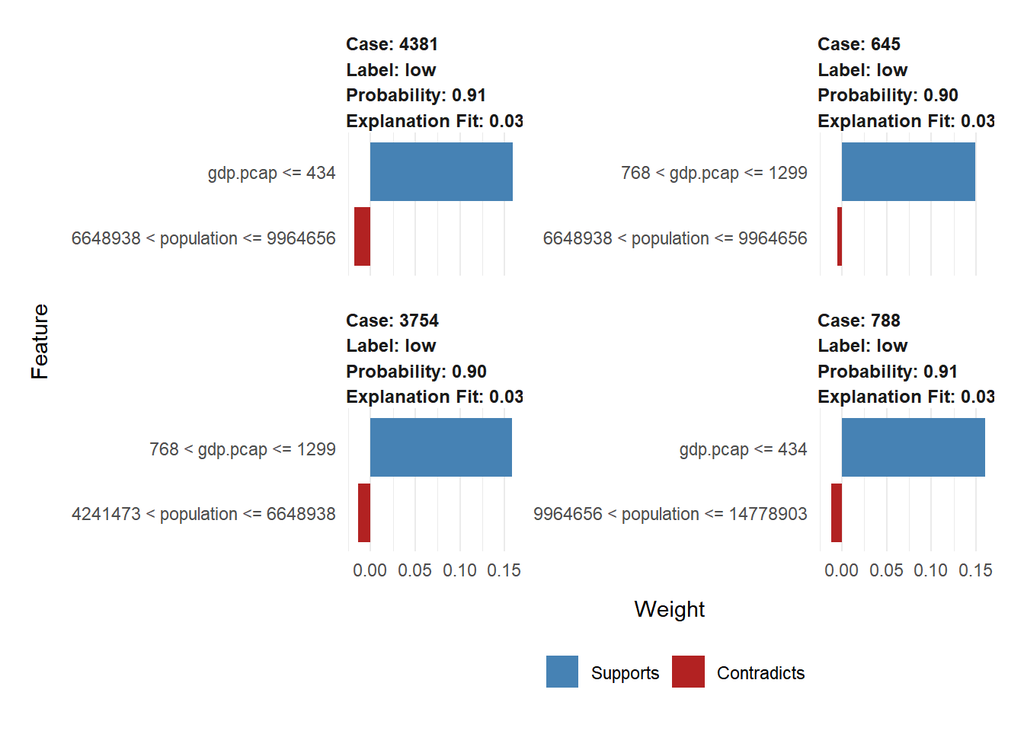

```r
# Define the model_type function
model_type.glm <- function(x, ...) {
  return("classification")
}

# Define the predict_model function, which type is glm
predict_model.glm <- function(model, newdata, ...) {
  predictions <- predict(model, newdata, type = "response")
  data.frame(low = 1 - predictions, high = predictions)
}

# Register to the global environment
assign("model_type.glm", model_type.glm, envir = .GlobalEnv)
assign("predict_model.glm", predict_model.glm, envir = .GlobalEnv)

# Select feature columns
features <- c("gdp.pcap", "population")

# Create an explainer for the logistic regression model
explainer_logit <- lime(train_data[features], model = logit_model, bin_continuous = TRUE, n_bins = 10)

# Select the random test data samples to explain
set.seed(4009)
cases <- sample(1:nrow(test_data), 4)
example <- test_data[cases, features]

# Explain the logistic regression model
explanation_logit <- lime::explain(example, explainer_logit, n_labels = 1, n_features = 4)

# Visualise the explanation of the logistic regression model
plot_features(explanation_logit)
```

# 3. Clustering

What we are exploring is the clustering of the numerical features(population and gdp per capita), so it is not appropriate to use Hamming distance, which is better at handling categorical variables. I chose the default Euclidean distance used in the K-means algorithm as the distance measure since it represents the straight-line distance between two points.

It can be seen from the plots that when k is equal to 9, the CH index is maximized, indicating the best clustering performance; when k is equal to 2, the ASW is the closest to 1, showing good separation and compactness of the samples; when k is equal to 3, it is the second best for the CH index and ASW.

By plotting scatter plots for clustering results when k equals 2, 3, and 9, we can conclude that when the number of clusters is 3, both indices perform well, providing a reasonable partition of the data while preventing overfitting, making 3 the optimal number of clusters.

## 3.1 preparations for clustering

```r
# Select the feature variables for clustering
cluster_data <- data %>% select(gdp.pcap, population) %>% na.omit()

# Set the random seed to ensure reproducibility
set.seed(4009)
```

## 3.2 Determine the best number of clusters by the Calinski-Harabasz Index (“CH Index”) and the Average Silhouette Width (“ASW”)

```r
# Set the random seed for reproducibility
set.seed(4009)

# Evaluate the number of clusters based on CH Index
kmClustering.ch <- kmeansruns(cluster_data, krange = 2:10, criterion = "ch")

# Evaluate the number of clusters based on ASW
kmClustering.asw <- kmeansruns(cluster_data, krange = 2:10, criterion = "asw")

# Check the optimal number of clusters based on the above two algorithms.
kmClustering.ch$bestk
```

```
## [1] 9
```

```r
kmClustering.asw$bestk
```

```
## [1] 2
```

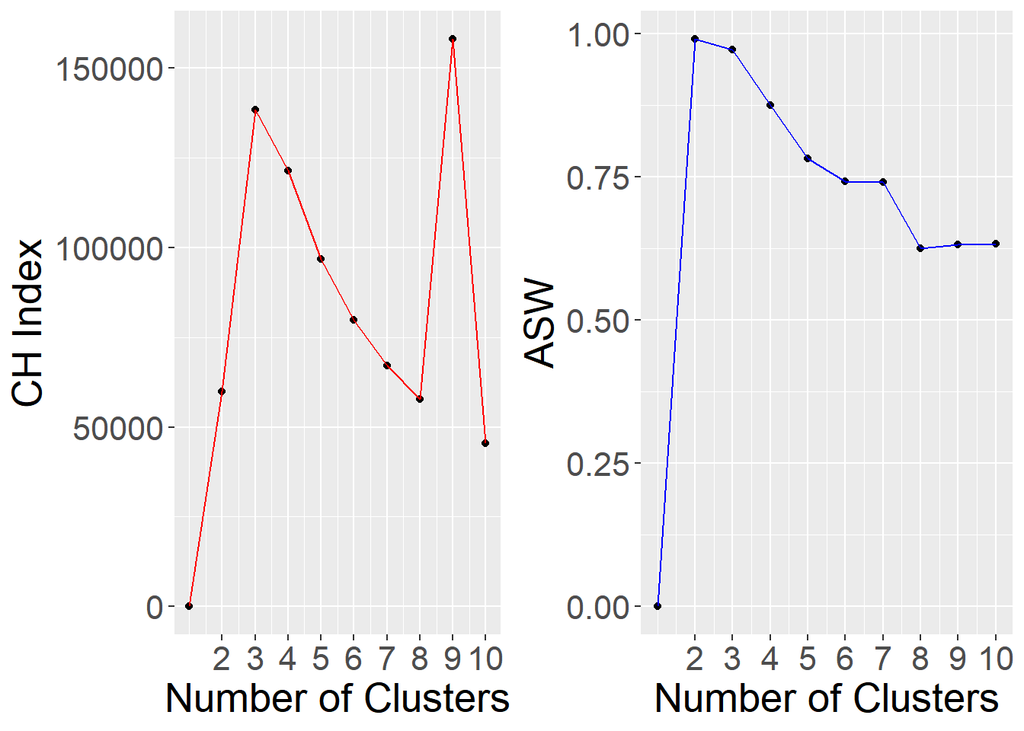

```r
# Create a dataframe for plotting
kmCritframe <- data.frame(k = 1:10, ch = kmClustering.ch$crit, asw = kmClustering.asw$crit)

# Plot the CH Index and ASW
fig1 <- ggplot(kmCritframe, aes(x = k, y = ch)) +
  geom_point() + geom_line(colour = "red") +
  scale_x_continuous(breaks = 2:10, labels = 2:10) +
  labs(y = "CH Index", x = "Number of Clusters") +
  theme(text = element_text(size = 20))

fig2 <- ggplot(kmCritframe, aes(x = k, y = asw)) +
  geom_point() + geom_line(colour = "blue") +
  scale_x_continuous(breaks = 2:10, labels = 2:10) +
  labs(y = "ASW", x = "Number of Clusters") +
  theme(text = element_text(size = 20))

# Display the two plots side by side
grid.arrange(fig1, fig2, nrow = 1)
```

## 3.3 Assume the number of clusters is 2

The data points are divided into two main categories, with the left cluster containing the majority of points concentrated in countries with smaller population sizes, while the right cluster mainly contains data in regions with larger populations. This indicates a significant distinction between countries with low population and those with high population, but there is greater dispersion within the left one, showing a large variance in GDP per capita.

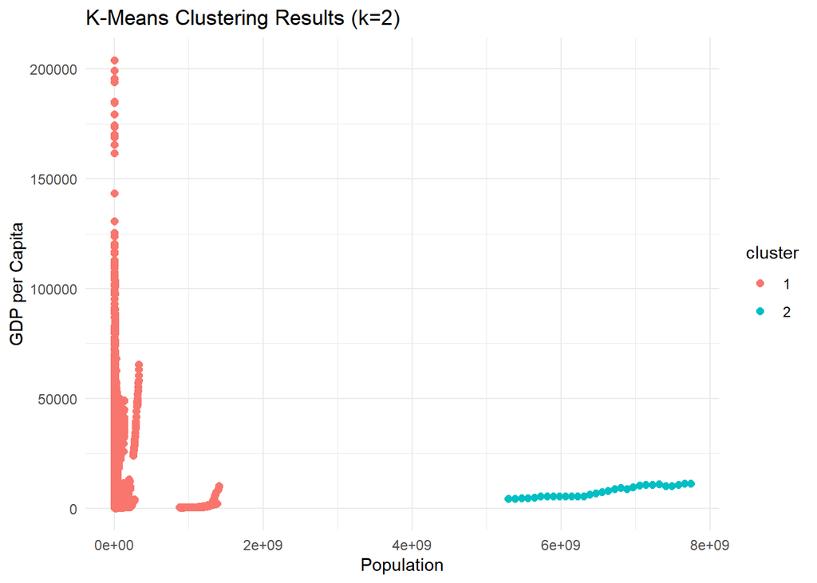

```r
# Apply K-Means clustering algorithm with 2 clusters
k2 <- 2
kmeans_result_2 <- kmeans(cluster_data, centers = k2, nstart = 20)

# Add the clustering results to the original data set
cluster_data_2 <- cluster_data %>% mutate(cluster = factor(kmeans_result_2$cluster))

# Plot the clustering results as a scatter plot
ggplot(cluster_data_2, aes(x = population, y = gdp.pcap, color = cluster)) +
  geom_point(size = 2) +
  labs(title = "K-Means Clustering Results (k=2)",
       x = "Population",
       y = "GDP per Capita") +
  theme_minimal()
```

## 3.4 Assume the number of clusters is 3

After dividing the data points into three categories, it is possible to further distinguish a group of countries with moderate population sizes, which differ from countries with lower and higher populations. This division allows the model to better display disparities between countries without leading to overfitting.

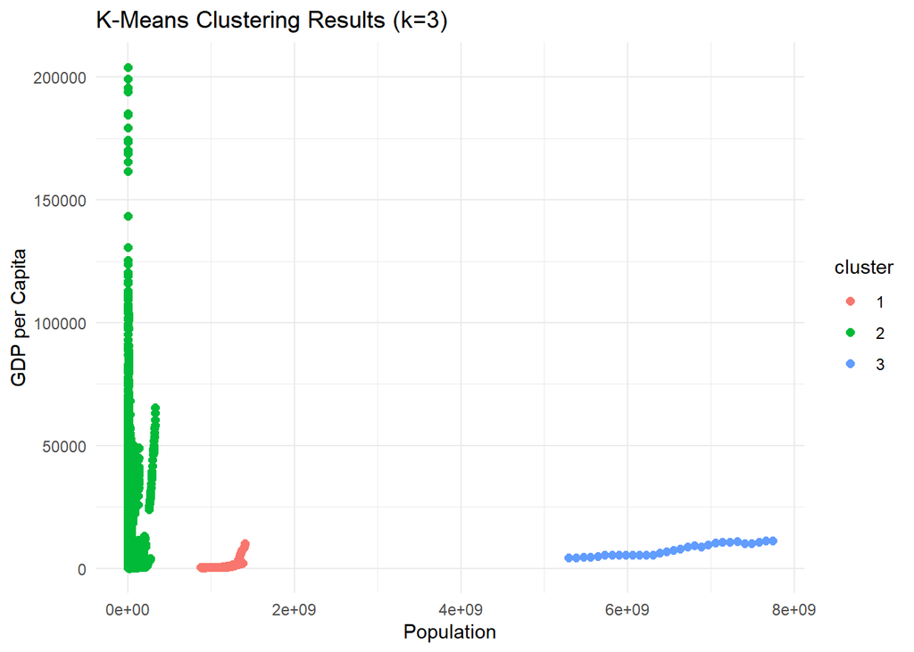

```r
# Apply K-Means clustering algorithm with 3 clusters
k3 <- 3
kmeans_result_3 <- kmeans(cluster_data, centers = k3, nstart = 20)

# Add the clustering results to the original data set
cluster_data_3 <- cluster_data %>% mutate(cluster = factor(kmeans_result_3$cluster))

# Plot the clustering results as a scatter plot
ggplot(cluster_data_3, aes(x = population, y = gdp.pcap, color = cluster)) +
  geom_point(size = 2) +
  labs(title = "K-Means Clustering Results (k=3)",
       x = "Population",
       y = "GDP per Capita") +
  theme_minimal()
```

## 3.5 Assume the number of clusters is 9

When the number of clusters is increased to 9, the data points are divided into more smaller categories, making it look rather confusing, especially for countries with lower population. Some clusters contain only a few data points, leading to overfitting of the small clusters and making it difficult to obtain meaningful information.

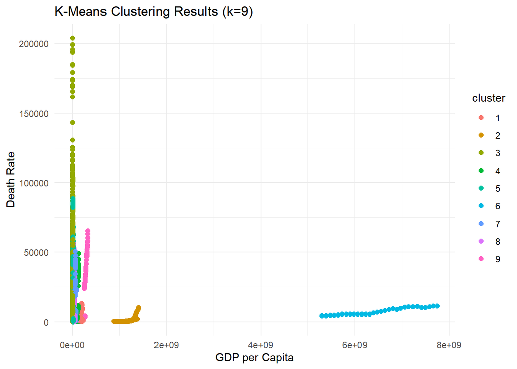

```r
# Apply K-Means clustering algorithm with 9 clusters
k9 <- 9
kmeans_result_9 <- kmeans(cluster_data, centers = k9, nstart = 20)

# Add the clustering results to the original data set
cluster_data_9 <- cluster_data %>% mutate(cluster = factor(kmeans_result_9$cluster))

# Plot the clustering results as a scatter plot
ggplot(cluster_data_9, aes(x = population, y = gdp.pcap, color = cluster)) +
  geom_point(size = 2) +
  labs(title = "K-Means Clustering Results (k=9)",
       x = "GDP per Capita",
       y = "Death Rate") +
  theme_minimal()
```

# Reference

I have asked ChatGPT to give me some advice about the structure of the code for certain functions. And the Model is GPT 4o.

[1] In section 1.3, I asked the advice from the GPT about how to change to row in to the same column.

[2] In section 1.5, I asked the advice from the GPT the structure of the inner join before I replace the arguments.

[3] In section 2.5, I defined the model_type.rpart and predict_model.rpart functions to ensure that the LIME model can correctly recognize the decision tree model type. This part of the code was suggested in my conversation with ChatGPT to resolve the error where the model type could not be recognized when generating the HTML file. Without being registered to the global environment, the model_type() and predict_model() functions are restricted to the local environment.